# Marker union rarefaction

How the non-informative share and the founder missing data change as donors are added to the union (sampling simulation, no reads)

Author

Fausto Rodríguez-Zapata

Published

September 26, 2026

**What this is.** A fast sampling simulation of the marker union + gap filling as the number of donors grows from 2 (the zealbc1 notebook 06 pilot) to 95 (all ZEAL donors). No sequences and no reads: each site gets a population allele frequency, each donor haplotype draws its allele, discovery and gap filling act as probabilities. It answers two questions before any genotyping run: does each donor end up non-informative (REF) at ~70 % of union sites, as on the SNP50K positions, and how much founder missing data does the union carry at 95 donors.

**NoteOutcome (2026-09-26)**

- With standing variation dominated by rare alleles (neutral spectrum) and the measured discovery sensitivity (~10 % of the AnchorWave SNPs), each donor is **non-informative at ~68 % of the union at 95 donors**, in line with the SNP50K expectation. A flat allele-frequency spectrum never gets there (< 50 %).
- Founder missing data per donor at 95 donors is **20–30 % of union sites**, depending on how often gaps where the donor is truly REF end up missing. In the genotype matrix that is **~3–5 % of cells**, because a missing founder allele only blanks lines that carry the donor segment there.

```r
library(dplyr)
library(tidyr)
library(ggplot2)
set.seed(20260926)
theme_set(theme_bw(base_size = 11))
```

## 1. Measured inputs

All numbers are chr10. The low-copy ranges are the lowcopy BED: 8,095 intervals, 26.0 Mb.

**Ceiling for discovery: the AnchorWave SNPs.** The pairwise AnchorWave alignment of each founder assembly against B73 is the reference variant space; no discovery method can find more. Source: `qcset_designB/chr10/build_founder_gvcf/<F>_PERFECT.summary.txt`.

```r
ceiling_tbl <- tibble(
  founder = c("Gigi (Zd)", "TIL18 (Zx)"),
  snps_chr10 = c(2090083, 2031229),
  snps_lowcopy = c(412493, 444982)
)
knitr::kable(ceiling_tbl, format.args = list(big.mark = ","),
             col.names = c("founder", "AnchorWave SNPs vs B73, chr10", "in the low-copy ranges"))
```

| founder | AnchorWave SNPs vs B73, chr10 | in the low-copy ranges |
| --- | --- | --- |
| Gigi (Zd) | 2,090,083 | 412,493 |
| TIL18 (Zx) | 2,031,229 | 444,982 |

**Discovered per donor (pilot).** Own tier-A sites of the two mexicana donors of zealbc1 notebook 06; sensitivity is measured against the TIL18 (mexicana) ceiling.

```r
pilot <- tibble(
  donor = c("Zx.0540_P3", "Zx.0570_P2"),
  own_alt = c(40874, 54328),
  gaps = c(41832, 28378),
  gap_ref = c(12496, 11531),
  gap_alt = c(17517, 7768),
  gap_missing = c(11819, 9079)
) |>
  mutate(union = own_alt + gaps,
         sensitivity = own_alt / ceiling_tbl$snps_lowcopy[2],
         missing_of_union = gap_missing / union,
         missing_of_gaps = gap_missing / gaps)
knitr::kable(pilot |> select(donor, own_alt, sensitivity, union, gaps, gap_ref, gap_alt, gap_missing, missing_of_union),
             digits = 3, format.args = list(big.mark = ","))
```

| donor | own_alt | sensitivity | union | gaps | gap_ref | gap_alt | gap_missing | missing_of_union |
| --- | --- | --- | --- | --- | --- | --- | --- | --- |
| Zx.0540_P3 | 40,874 | 0.092 | 82,706 | 41,832 | 12,496 | 17,517 | 11,819 | 0.143 |
| Zx.0570_P2 | 54,328 | 0.122 | 82,706 | 28,378 | 11,531 | 7,768 | 9,079 | 0.110 |

**Usable sequence after mapping.** Reads simulated from each chr10 assembly (wgsim 2×150), mapped to the whole B73 with minibwa, kept at MAPQ ≥ 20 (`qcset_designB/chr10/alignment_sim/*.flagstat.txt`; simulated pairs = length × depth / 300).

```r
mapping <- tibble(
  source = c("B73", "TIL18 (mexicana)", "Gigi (diploperennis)"),
  length_bp = c(152435371, 144.6e6, 147.2e6),
  depth = c(20, 22, 22),
  kept = c(17560561, 9076719, 7250233)
) |>
  mutate(simulated = 2 * floor(length_bp * depth / 300), share_kept = kept / simulated)
knitr::kable(mapping |> select(source, simulated, kept, share_kept), digits = 3, format.args = list(big.mark = ","))
```

| source | simulated | kept | share_kept |
| --- | --- | --- | --- |
| B73 | 20,324,716 | 17,560,561 | 0.864 |
| TIL18 (mexicana) | 21,208,000 | 9,076,719 | 0.428 |
| Gigi (diploperennis) | 21,589,332 | 7,250,233 | 0.336 |

## 2. Model

- **Standing variation.** Site $s$ has population ALT frequency $p_s$, drawn from the neutral spectrum $f(p) \propto 1/p$ on $\{1/2000, \dots, 1999/2000\}$, or from a flat spectrum $p_s \sim U(0.001, 0.999)$ as the contrast.
- **Donors.** Donor haplotype $H_d$ carries ALT at $s$ with probability $p_s$, independently across donors.
- **Discovery.** A donor finds each of its own ALT sites with sensitivity $r$ (measured ≈ 0.1; 0.05 and 0.15 as the range).
- **Union and gaps.** The union $U_n$ of $n$ donors is every site found in at least one of them. For donor $d$, own sites are those it found; gaps are $U_n$ minus own. A gap is truly REF (non-informative) or truly ALT (an allele the donor carries but did not find).
- **Gap filling.** A gap ends up missing with rate $m_\mathrm{REF}$ if truly REF and $m_\mathrm{ALT}$ if truly ALT. Two models, each calibrated so that **2 donors give 15 % missing** (the pilot):
  - *flat*: $m_\mathrm{REF} = m_\mathrm{ALT} = m$;
  - *REF easy*: $m_\mathrm{REF} = 0.05$, $m_\mathrm{ALT}$ calibrated.
- **Reported per donor**, averaged over donors: non-informative share of $U_n$ (donor truly REF), own and gap shares, missing share. Donors are added one at a time to the same simulated set, so each curve is a rarefaction curve.

```r
n_sites <- 2e5
n_max <- 95
donor_steps <- c(2:10, 15, 20, 30, 40, 60, 80, 95)
pilot_missing <- 0.15
m_ref_easy <- 0.05

draw_freqs <- function(sfs, n_sites) {
  if (sfs == "neutral 1/p") {
    i <- 1:1999
    sample(i / 2000, n_sites, replace = TRUE, prob = 1 / i)
  } else {
    runif(n_sites, 0.001, 0.999)
  }
}

rarefy <- function(p, r, steps) {
  alt <- matrix(runif(n_max * length(p)) < rep(p, each = n_max), nrow = n_max)
  found <- alt & matrix(runif(n_max * length(p)) < r, nrow = n_max)
  bind_rows(lapply(steps, function(n) {
    fo <- found[1:n, , drop = FALSE]
    in_union <- colSums(fo) > 0
    own_m <- fo[, in_union, drop = FALSE]
    tru_m <- alt[1:n, in_union, drop = FALSE]
    tibble(donors = n, union_sites = sum(in_union),
           noninformative = mean(!tru_m), own = mean(own_m),
           gap_ref = mean(!own_m & !tru_m), gap_alt = mean(!own_m & tru_m))
  }))
}

scenarios <- expand_grid(sfs = c("neutral 1/p", "flat p"), r = c(0.05, 0.1, 0.15))
sim <- scenarios |>
  group_by(sfs) |>
  group_modify(function(g, key) {
    p <- draw_freqs(key$sfs, n_sites)
    bind_rows(lapply(g$r, function(r) rarefy(p, r, donor_steps) |> mutate(r = r)))
  }) |>
  ungroup() |>
  mutate(gap = gap_ref + gap_alt)
```

```r
calib <- sim |>
  filter(donors == 2) |>
  transmute(sfs, r,
            m_flat = pilot_missing / gap,
            m_alt_ref_easy = (pilot_missing - gap_ref * m_ref_easy) / gap_alt)

res <- sim |>
  left_join(calib, by = c("sfs", "r")) |>
  mutate(missing_flat = gap * m_flat,
         missing_ref_easy = if_else(m_alt_ref_easy <= 1, gap_ref * m_ref_easy + gap_alt * m_alt_ref_easy, NA_real_))

knitr::kable(calib, digits = 2, col.names = c("SFS", "sensitivity r", "m (flat)", "m_ALT (REF easy)"),
             caption = "Gap missing rates calibrated to 15 % missing at 2 donors. A value above 1 means the model cannot reproduce the pilot.")
```

Gap missing rates calibrated to 15 % missing at 2 donors. A value above 1 means the model cannot reproduce the pilot.

| SFS | sensitivity r | m (flat) | m_ALT (REF easy) |
| --- | --- | --- | --- |
| flat p | 0.05 | 0.30 | 0.44 |
| flat p | 0.10 | 0.31 | 0.46 |
| flat p | 0.15 | 0.32 | 0.48 |
| neutral 1/p | 0.05 | 0.30 | 0.58 |
| neutral 1/p | 0.10 | 0.31 | 0.58 |
| neutral 1/p | 0.15 | 0.31 | 0.62 |

## 3. Non-informative share

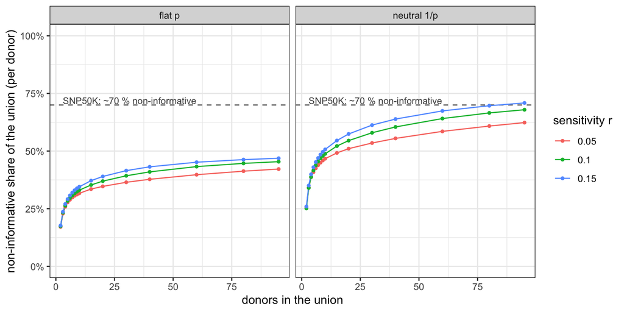

Figure 1

```r
ggplot(res, aes(donors, noninformative, colour = factor(r))) +
  geom_hline(yintercept = 0.7, linetype = "dashed", colour = "grey40") +
  annotate("text", x = 3, y = 0.72, label = "SNP50K: ~70 % non-informative", hjust = 0, size = 3, colour = "grey30") +
  geom_line() + geom_point(size = 1) +
  facet_wrap(~sfs) +
  scale_y_continuous(labels = scales::percent, limits = c(0, 1)) +
  labs(x = "donors in the union", y = "non-informative share of the union (per donor)", colour = "sensitivity r")
```

## 4. Founder missing data

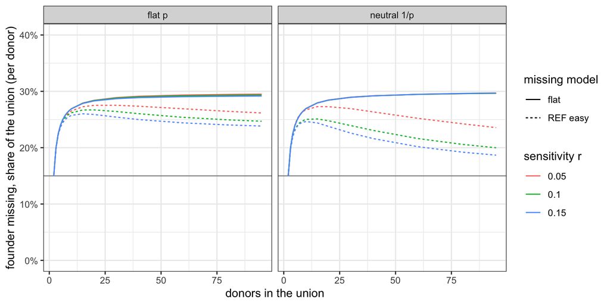

Figure 2

```r
res |>
  select(sfs, r, donors, flat = missing_flat, `REF easy` = missing_ref_easy) |>
  pivot_longer(c(flat, `REF easy`), names_to = "missing model", values_to = "missing") |>
  filter(!is.na(missing)) |>
  ggplot(aes(donors, missing, colour = factor(r), linetype = `missing model`)) +
  geom_hline(yintercept = pilot_missing, colour = "grey60") +
  geom_line() +
  facet_wrap(~sfs) +
  scale_y_continuous(labels = scales::percent, limits = c(0, 0.4)) +
  labs(x = "donors in the union", y = "founder missing, share of the union (per donor)", colour = "sensitivity r")
```

**Where the union sites come from** (neutral spectrum, $r = 0.1$): as donors are added, own sites shrink to a few percent and gaps dominate; most new gaps are sites where the donor is REF.

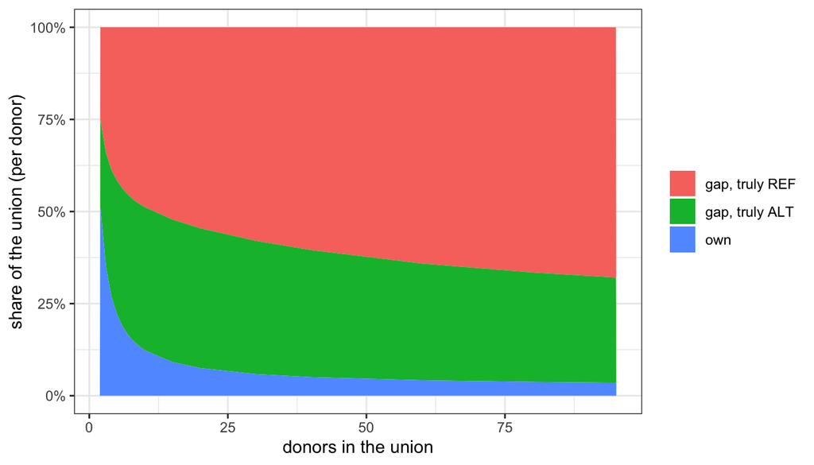

Figure 3

```r
res |>
  filter(sfs == "neutral 1/p", r == 0.1) |>
  select(donors, own, `gap, truly ALT` = gap_alt, `gap, truly REF` = gap_ref) |>
  pivot_longer(-donors, names_to = "class", values_to = "share") |>
  mutate(class = factor(class, levels = c("gap, truly REF", "gap, truly ALT", "own"))) |>
  ggplot(aes(donors, share, fill = class)) +
  geom_area() +
  scale_y_continuous(labels = scales::percent) +
  labs(x = "donors in the union", y = "share of the union (per donor)", fill = NULL)
```

## 5. What it means for the genotype matrix

A missing founder allele $D_{ds}$ only blanks the genotype of a line where the line carries the donor segment at $s$ ($G_s = x \cdot D_{ds}$, math supplement Eq. S5.1). In BC$_2$S$_3$ that is $1 - 55/64 = 14.1\,\%$ of lines at a site, so the share of missing genotype cells is roughly the founder missing share × 0.141.

```r
carrier <- 1 - 55 / 64
res |>
  filter(sfs == "neutral 1/p", r == 0.1, donors %in% c(2, 10, 20, 40, 95)) |>
  transmute(donors, noninformative, missing_flat, missing_ref_easy,
            cells_flat = missing_flat * carrier, cells_ref_easy = missing_ref_easy * carrier) |>
  knitr::kable(digits = 3, col.names = c("donors", "non-informative", "founder missing (flat)", "founder missing (REF easy)",
                                         "missing cells (flat)", "missing cells (REF easy)"))
```

| donors | non-informative | founder missing (flat) | founder missing (REF easy) | missing cells (flat) | missing cells (REF easy) |
| --- | --- | --- | --- | --- | --- |
| 2 | 0.251 | 0.150 | 0.150 | 0.021 | 0.021 |
| 10 | 0.488 | 0.270 | 0.250 | 0.038 | 0.035 |
| 20 | 0.545 | 0.284 | 0.248 | 0.040 | 0.035 |
| 40 | 0.605 | 0.292 | 0.231 | 0.041 | 0.032 |
| 95 | 0.679 | 0.297 | 0.200 | 0.042 | 0.028 |

## 6. Checks and caveats

- **Pilot check at 2 donors.** The simulation gives gaps at ~49 % of the union with ~23 % of the union truly-ALT gaps ($r = 0.1$); the pilot has gaps at 51 % and 34 % of the union, with 42 % and 27 % of gaps filled ALT.
- **Sensitivity is a ceiling-relative figure.** $r$ is measured against the AnchorWave SNPs, the ceiling for any discovery method.
- **Assumptions:** one panmictic mexicana population (no structure among donors), donors independent, the same sensitivity for every donor and every allele frequency, and a missing rate that depends only on whether the gap is truly REF or ALT. A real union across taxa would behave differently; this simulates a same-taxon union.
- **Absolute union sizes are arbitrary** (they scale with the 200,000 simulated sites); only the shares are meaningful.